# Final Project

Exploratory analysis and inferential statistics

Joaquin Menendez (jm622)

December 4, 2018

# Influence of Semantic Similarity and Stimulus Onset Asynchrony on Semantic Subliminal Processing

> *Studies employing a masked priming paradigm have observed that subliminal stimuli could be processed on a semantic level. Semantic categorization of a consciously perceived stimulus could be facilitated by the presentation of a former stimulus that was not consciously perceived (subliminal). This facilitation is usually measured as the reaction time employed to respond to a task. When this facilitation occurs between congruent pairs of stimuli (from the same category) and does not occur between incongruent pairs (from different categories) is called congruency priming effect. Two principal factors modulate the subliminal priming effect, the semantic similarity between stimuli and the SOA. Semantic similarity refers to the similarity in meaning or overlap of features between two words. The greater the similarity, the bigger the facilitation. Another factor that modulates priming effect is the interval between the onset of the first stimulus and the onset of the second stimulus of the par (SOA: stimulus onset asynchrony), showing that the bigger the SOA, the lower priming effect. Despite the fact that these two phenomena have been extensively studied, it has not been studied the influence of semantic strength has not been studied together with SOA duration. The goal of this study is to observe if semantic relatedness (strongly and weakly related pairs) could modulate congruency priming effect duration. To evaluate this, both semantic relatedness (strong and weak) and SOA were manipulated in a subliminal semantic priming task.*

### Checking correct responses

```r
#Some exploratory metrics ----
summary(dfpriming)
##    Num.Trial         Answer             RT               Prime
##  Min.   : -9.0   Min.   :0.0000   Min.   :0.05859   abeja   :  400
##  1st Qu.: 57.0   1st Qu.:1.0000   1st Qu.:0.46260   aguila  :  400
##  Median :123.5   Median :1.0000   Median :0.52275   arana   :  400
##  Mean   :123.5   Mean   :0.9493   Mean   :0.55211   ardilla :  400
##  3rd Qu.:190.0   3rd Qu.:1.0000   3rd Qu.:0.59464   avestruz:  400
##  Max.   :256.0   Max.   :1.0000   Max.   :1.98419   bota    :  400
##                                   NA's   :75        (Other) :24200
##         Target      Categoria   Key_pressed   correct_key
##  caballo   : 1600   nr :12800   rctrl:13290   rctrl:13566
##  cabra     : 1600   sra: 3681   lctrl:13225   lctrl:13034
##  cebra     : 1600   sro: 3719   NA's :   85
##  cigarrillo: 1600   wra: 3200
##  clavo     : 1600   wro: 3200
##  gato      : 1600
##  (Other)   :17000
##  Prime_aparition_time         ID             Age              Gender
##  Min.   :0.02384      150_10_03:  266   Min.   :18.00   Femenino :19152
##  1st Qu.:0.03336      150_12_05:  266   1st Qu.:19.00   Masculino: 7448
##  Median :0.03338      150_12_55:  266   Median :19.00
##  Mean   :0.03338      150_13_04:  266   Mean   :21.52
##  3rd Qu.:0.03340      150_13_36:  266   3rd Qu.:21.25
##  Max.   :0.06282      150_14_00:  266   Max.   :46.00
##                       (Other)  :25004
##  Neuro_A    Medication_A Works_A     Sleep_hours      prelikert
##  No:26334   No:24472     No:14098   Min.   :5.000   Min.   :1.00
##  Si:  266   Si: 2128     Si:12502   1st Qu.:5.000   1st Qu.:1.00
##                                     Median :6.000   Median :2.00
##                                     Mean   :6.178   Mean   :2.36
##                                     3rd Qu.:7.000   3rd Qu.:3.00
##                                     Max.   :8.000   Max.   :7.00
##                                     NA's   :2660
##    postlikert     similarity         SOA      Animales Correctas
##  Min.   :1.00   Min.   :1.000   Min.   : 66   Min.   : 7.00
##  1st Qu.:2.00   1st Qu.:1.000   1st Qu.:150   1st Qu.:36.00
##  Median :2.00   Median :1.000   Median :233   Median :41.50
##  Mean   :2.67   Mean   :2.631   Mean   :194   Mean   :41.78
##  3rd Qu.:4.00   3rd Qu.:4.000   3rd Qu.:254   3rd Qu.:50.25
##  Max.   :6.00   Max.   :7.000   Max.   :317   Max.   :58.00
##                 NA's   :1000
##  Animales Incorrectas Objetos COrrectas Objetos Incorrectas
##  Min.   : 6.00        Min.   :24.00     Min.   : 2.00
##  1st Qu.:13.75        1st Qu.:34.00     1st Qu.:17.00
##  Median :22.50        Median :39.00     Median :23.00
##  Mean   :22.22        Mean   :39.53     Mean   :22.47
##  3rd Qu.:28.00        3rd Qu.:45.00     3rd Qu.:28.00
##  Max.   :57.00        Max.   :60.00     Max.   :38.00
##
##     HitRate          FA rate            dprime        Relation
##  Min.   :0.1094   Min.   :0.03125   Min.   :-0.3363   nr:12800
##  1st Qu.:0.5625   1st Qu.:0.26562   1st Qu.: 0.3148   WR: 6400
##  Median :0.6484   Median :0.35938   Median : 0.8163   SR: 7400
##  Mean   :0.6528   Mean   :0.35109   Mean   : 0.8412
##  3rd Qu.:0.7852   3rd Qu.:0.43750   3rd Qu.: 1.3295
##  Max.   :0.9062   Max.   :0.59375   Max.   : 2.2650
##
```

```r
#lets explore by Correct Answer
dfpriming[dfpriming$Answer == '1',] %>%
  group_by(SOA, Relation) %>%
  summarise(RT.mean = mean(RT), RT.sd = sd(RT))
```

```
## # A tibble: 12 x 4
## # Groups:   SOA [?]
##      SOA Relation RT.mean RT.sd
##    <dbl> <fct>      <dbl> <dbl>
##  1    66 nr         0.552 0.132
##  2    66 WR         0.540 0.128
##  3    66 SR         0.553 0.156
##  4   150 nr         0.566 0.164
##  5   150 WR         0.553 0.158
##  6   150 SR         0.561 0.181
##  7   233 nr         0.527 0.121
##  8   233 WR         0.519 0.118
##  9   233 SR         0.533 0.144
## 10   317 nr         0.572 0.173
## 11   317 WR         0.565 0.171
## 12   317 SR         0.567 0.187
```

### Checking that all subject answered more o less correctly

```r
all_answer <- dfpriming %>%
          group_by(ID,SOA) %>%
          count(Answer)
```

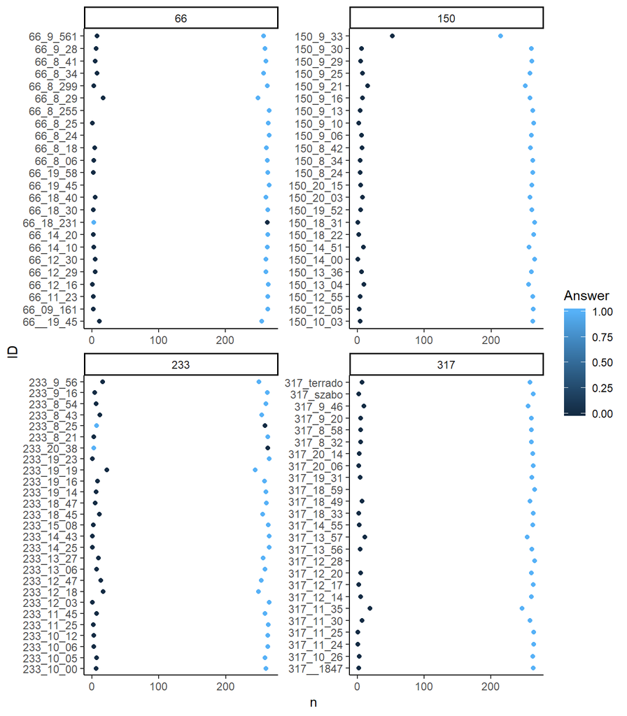

```r
ggplot2::ggplot(data = all_answer) + geom_point(mapping = aes(x= ID, y=n, color = Answer)) + coord_flip() + facet_wrap(~SOA, scales = 'free')+  theme_classic()
```

We can see that subjects 66_18_231, 233_8_25 and 233_20_38 shown a abnormal pattern of response. Asking to the experimenters they responded that this subjects misunderstood the instructions and answered with opposite keys. In other words, they answered to Animals Images with the “Object key” (right control) and with the “Animal Key” (left control) to the object images. The responses of this three subject were reverted.

### Checking missing values

```r
# Usually for primming effects expriments missing values are not considered. And the focus is only on correct answers.
# We will need to remove NA responses and the training sets.
# BUT FIRST WE WOULD PERFORM A QUICK ANALYSIS ON THE NA RESPONSE VALUES to see if there is an assymetry on the NA 's distribution.

dffinal = dfpriming_corrected[dfpriming_corrected$Num.Trial > 0,] #Delete training trials

NA_by_Categoria = summaryBy(Key_pressed~Categoria, data=dffinal[is.na(dffinal$Key_pressed),],FUN =  summary)
NA_by_Categoria[c(1,8)]
##   Categoria Key_pressed.NA's
## 1        nr               24
## 2       sra                5
## 3       sro                6
## 4       wra                8
## 5       wro                4
NA_by_Relation = summaryBy(Key_pressed~Relation, data=dffinal[is.na(dffinal$Key_pressed),],FUN =  summary)
NA_by_Relation[c(1,8)]
##   Relation Key_pressed.NA's
## 1       nr               24
## 2       WR               12
## 3       SR               11
```

There is no evidence of preference of NA response given a specific Relationship. Given the low numbers of NAs we are going to use a ‘classical experimental approach’ and we are not going to study trials were subjects did not response.

### Summary of variables by Group

```r
df_summarized %>%
  group_by(SOA, Relation) %>%
  summarize(mean_RT = mean(RT), sd_RT= sd(RT))
```

```
## # A tibble: 12 x 4
## # Groups:   SOA [?]
##    SOA   Relation mean_RT  sd_RT
##    <fct> <fct>      <dbl>  <dbl>
##  1 66    nr         0.542 0.105
##  2 66    WR         0.532 0.103
##  3 66    SR         0.532 0.107
##  4 150   nr         0.549 0.115
##  5 150   WR         0.539 0.122
##  6 150   SR         0.532 0.112
##  7 233   nr         0.520 0.0907
##  8 233   WR         0.512 0.0901
##  9 233   SR         0.516 0.0956
## 10 317   nr         0.557 0.141
## 11 317   WR         0.547 0.132
## 12 317   SR         0.546 0.141
```

```r
df_summarized %>%
  group_by(SOA) %>%
  summarize(mean_dprime = mean(dprime), sd_dprime= sd(dprime))
```

```
## # A tibble: 4 x 3
##   SOA   mean_dprime sd_dprime
##   <fct>       <dbl>     <dbl>
## 1 66          0.254     0.321
## 2 150         0.717     0.437
## 3 233         1.07      0.486
## 4 317         1.27      0.552
```

```r
df_summarized %>%
  group_by(SOA) %>%
  summarize(similarity.mean = mean(similarity), sd.similarity= sd(similarity))
```

```
## # A tibble: 4 x 3
##   SOA   similarity.mean sd.similarity
##   <fct>           <dbl>         <dbl>
## 1 66               2.70          2.13
## 2 150              2.64          2.18
## 3 233              2.53          2.08
## 4 317              2.68          2.16
```

```r
#Age
psych::describe(multiple_data[multiple_data$SOA== 66,]$Age)
##    vars  n  mean   sd median trimmed  mad min max range skew kurtosis   se
## X1    1 24 20.71 4.19   19.5    19.8 2.22  18  35    17 2.12     3.86 0.85
psych::describe(multiple_data[multiple_data$SOA== 150,]$Age)
##    vars  n  mean  sd median trimmed  mad min max range skew kurtosis   se
## X1    1 24 23.04 7.4     19    21.9 1.48  18  43    25 1.37     0.38 1.51
psych::describe(multiple_data[multiple_data$SOA== 233,]$Age)
##    vars  n  mean   sd median trimmed  mad min max range skew kurtosis   se
## X1    1 27 21.67 6.13     19   20.26 1.48  18  46    28 2.84     7.71 1.18
psych::describe(multiple_data[multiple_data$SOA== 317,]$Age)
##    vars  n  mean   sd median trimmed  mad min max range skew kurtosis   se
## X1    1 25 20.68 3.47     20    20.1 1.48  18  34    16 2.33     5.97 0.69
```

```r
#Sleeping
psych::describe(multiple_data[multiple_data$SOA== 66,]$Sleep_hours)
##    vars  n mean   sd median trimmed  mad min max range skew kurtosis   se
## X1    1 23  6.3 0.93      6    6.26 1.48   5   8     3 0.39    -0.78 0.19
psych::describe(multiple_data[multiple_data$SOA== 150,]$Sleep_hours)
##    vars  n mean   sd median trimmed  mad min max range skew kurtosis   se
## X1    1 20  6.1 1.17      6       6 1.48   5   8     3 0.58    -1.23 0.26
psych::describe(multiple_data[multiple_data$SOA== 233,]$Sleep_hours)
##    vars  n mean   sd median trimmed  mad min max range skew kurtosis   se
## X1    1 25  6.2 0.96      6    6.14 1.48   5   8     3 0.16    -1.15 0.19
psych::describe(multiple_data[multiple_data$SOA== 317,]$Sleep_hours)
##    vars  n mean   sd median trimmed mad min max range skew kurtosis   se
## X1    1 22 6.09 0.75      6    6.06   0   5   8     3 0.51     0.11 0.16
```

```r
#Gender
summary(multiple_data[multiple_data$SOA== 66,]$Gender)
##  Femenino Masculino
##        17         7
summary(multiple_data[multiple_data$SOA== 150,]$Gender)
##  Femenino Masculino
##        16         8
summary(multiple_data[multiple_data$SOA== 233,]$Gender)
##  Femenino Masculino
##        18         9
summary(multiple_data[multiple_data$SOA== 317,]$Gender)
##  Femenino Masculino
##        21         4
```

Despite of some subtle differences product of the random groupping, groups seem to be balanced on Age, sleep hours and Gender.

##### According to Ortells et. al (2016), to check if subjects did not conciously proccessed the prime stimuli on the experimental task, the dprime mean of the group on the visibility test must not be different from 0.

```r
t.test(nr[nr$SOA == 66,]$dprime, mu=0)
##
##  One Sample t-test
##
## data:  nr[nr$SOA == 66, ]$dprime
## t = 3.7823, df = 23, p-value = 0.0009645
## alternative hypothesis: true mean is not equal to 0
## 95 percent confidence interval:
##  0.1146846 0.3915757
## sample estimates:
## mean of x
## 0.2531302
t.test(nr[nr$SOA == 150,]$dprime, mu=0)
##
##  One Sample t-test
##
## data:  nr[nr$SOA == 150, ]$dprime
## t = 7.8974, df = 23, p-value = 5.348e-08
## alternative hypothesis: true mean is not equal to 0
## 95 percent confidence interval:
##  0.5326334 0.9107019
## sample estimates:
## mean of x
## 0.7216677
t.test(nr[nr$SOA == 233,]$dprime, mu=0)
##
##  One Sample t-test
##
## data:  nr[nr$SOA == 233, ]$dprime
## t = 11.245, df = 26, p-value = 1.746e-11
## alternative hypothesis: true mean is not equal to 0
## 95 percent confidence interval:
##  0.8765768 1.2687412
## sample estimates:
## mean of x
##  1.072659
t.test(nr[nr$SOA == 317,]$dprime, mu=0)
##
##  One Sample t-test
##
## data:  nr[nr$SOA == 317, ]$dprime
## t = 11.271, df = 24, p-value = 4.521e-11
## alternative hypothesis: true mean is not equal to 0
## 95 percent confidence interval:
##  1.037767 1.503021
## sample estimates:
## mean of x
##  1.270394
```

We have some problems! All the dprimes values are different to 0. We would like to remove some subjects, this would have as consequence the lose of several subjects, would made impossible the use of parametric stats and also reduce the statistical power.

Checking dprime differences among groups

```r
#ANOVA for dprimes
leveneTest(multiple_data$dprime, multiple_data$SOA, center = median) #Homogeneity
## Levene's Test for Homogeneity of Variance (center = median)
##       Df F value Pr(>F)
## group  3  2.0749 0.1086
##       96
tapply(multiple_data$dprime, multiple_data$SOA, shapiro.test)
## $`66`
##
##  Shapiro-Wilk normality test
##
## data:  X[[i]]
## W = 0.96252, p-value = 0.491
##
##
## $`150`
##
##  Shapiro-Wilk normality test
##
## data:  X[[i]]
## W = 0.96042, p-value = 0.4469
##
##
## $`233`
##
##  Shapiro-Wilk normality test
##
## data:  X[[i]]
## W = 0.94877, p-value = 0.2001
##
##
## $`317`
##
##  Shapiro-Wilk normality test
##
## data:  X[[i]]
## W = 0.95507, p-value = 0.325
aov_dprime = aov(dprime~SOA,data= multiple_data)
summary(aov_dprime)
##             Df Sum Sq Mean Sq F value   Pr(>F)
## SOA          3  14.69   4.898   22.29 4.88e-11 ***
## Residuals   96  21.09   0.220
## ---
## Signif. codes:  0 '***' 0.001 '**' 0.01 '*' 0.05 '.' 0.1 ' ' 1
TukeyHSD(aov_dprime)
##   Tukey multiple comparisons of means
##     95% family-wise confidence level
##
## Fit: aov(formula = dprime ~ SOA, data = multiple_data)
##
## $SOA
##              diff          lwr       upr     p adj
## 150-66  0.4685375  0.114750671 0.8223243 0.0043817
## 233-66  0.8195288  0.475709835 1.1633478 0.0000001
## 317-66  1.0172640  0.667032961 1.3674951 0.0000000
## 233-150 0.3509913  0.007172353 0.6948103 0.0435404
## 317-150 0.5487266  0.198495479 0.8989576 0.0005018
## 317-233 0.1977352 -0.142423842 0.5378943 0.4297134
psych::describe(multiple_data[multiple_data$SOA== 150,]$dprime)
##    vars  n mean   sd median trimmed  mad   min  max range  skew kurtosis
## X1    1 24 0.72 0.45   0.82    0.73 0.57 -0.08 1.48  1.56 -0.22    -1.12
##      se
## X1 0.09
psych::describe(multiple_data[multiple_data$SOA== 233,]$dprime)
##    vars  n mean  sd median trimmed  mad  min  max range  skew kurtosis  se
## X1    1 27 1.07 0.5   1.16    1.07 0.51 0.28 2.16  1.88 -0.08    -0.88 0.1
psych::describe(multiple_data[multiple_data$SOA== 317,]$dprime)
##    vars  n mean   sd median trimmed  mad   min  max range  skew kurtosis
## X1    1 25 1.27 0.56   1.35    1.31 0.54 -0.28 2.26  2.54 -0.72     0.27
##      se
## X1 0.11
```

Variables are homogeneous (Levene Test F = 2.0749, p = 0.1086), and groups follow a normal distribution (Shapiro Wilk test, ps > .05 for all groups). There is statistical evidence of a difference among dprime per group F(3,96)=22.29 p < .001. The bigger the SOA, the bigger the dprime. It could be interpreted as the increase of SOA facilitates the conscious processing of the prime stimulus.

Checking Prelikert differences among groups

```r
leveneTest(multiple_data$prelikert, multiple_data$SOA, center = median) #Las variables son homogeneas
## Levene's Test for Homogeneity of Variance (center = median)
##       Df F value Pr(>F)
## group  3  0.1087 0.9548
##       96
tapply(multiple_data$prelikert, multiple_data$SOA, shapiro.test) # Not NORMAL
## $`66`
##
##  Shapiro-Wilk normality test
##
## data:  X[[i]]
## W = 0.84215, p-value = 0.001568
##
##
## $`150`
##
##  Shapiro-Wilk normality test
##
## data:  X[[i]]
## W = 0.69599, p-value = 8.918e-06
##
##
## $`233`
##
##  Shapiro-Wilk normality test
##
## data:  X[[i]]
## W = 0.84843, p-value = 0.001073
##
##
## $`317`
##
##  Shapiro-Wilk normality test
##
## data:  X[[i]]
## W = 0.86742, p-value = 0.003842
kruskal.test(prelikert~SOA,data= multiple_data) #Need to use a Kruskall Wallis
##
##  Kruskal-Wallis rank sum test
##
## data:  prelikert by SOA
## Kruskal-Wallis chi-squared = 6.7592, df = 3, p-value = 0.07998
pairwise.wilcox.test(multiple_data$prelikert, multiple_data$SOA, p.adjust.method = 'fdr') #The problem is between 150 and 317
## Warning in wilcox.test.default(xi, xj, paired = paired, ...): cannot
## compute exact p-value with ties

## Warning in wilcox.test.default(xi, xj, paired = paired, ...): cannot
## compute exact p-value with ties

## Warning in wilcox.test.default(xi, xj, paired = paired, ...): cannot
## compute exact p-value with ties

## Warning in wilcox.test.default(xi, xj, paired = paired, ...): cannot
## compute exact p-value with ties

## Warning in wilcox.test.default(xi, xj, paired = paired, ...): cannot
## compute exact p-value with ties

## Warning in wilcox.test.default(xi, xj, paired = paired, ...): cannot
## compute exact p-value with ties
##
##  Pairwise comparisons using Wilcoxon rank sum test
##
## data:  multiple_data$prelikert and multiple_data$SOA
##
##     66    150   233
## 150 0.325 -     -
## 233 0.511 0.196 -
## 317 0.325 0.091 0.511
##
## P value adjustment method: fdr
psych::describe(multiple_data[multiple_data$SOA== 66,]$prelikert)
##    vars  n mean   sd median trimmed  mad min max range skew kurtosis   se
## X1    1 24 2.21 1.22      2    2.05 1.48   1   5     4 0.87    -0.12 0.25
psych::describe(multiple_data[multiple_data$SOA== 150,]$prelikert)
##    vars  n mean   sd median trimmed mad min max range skew kurtosis  se
## X1    1 24 1.96 1.46      1     1.7   0   1   6     5 1.52     1.15 0.3
psych::describe(multiple_data[multiple_data$SOA== 233,]$prelikert)
##    vars  n mean   sd median trimmed  mad min max range skew kurtosis   se
## X1    1 27 2.52 1.45      2    2.35 1.48   1   6     5 0.91    -0.03 0.28
psych::describe(multiple_data[multiple_data$SOA== 317,]$prelikert)
##    vars  n mean   sd median trimmed  mad min max range skew kurtosis   se
## X1    1 25 2.72 1.43      2    2.57 1.48   1   7     6 1.05     0.96 0.29
```

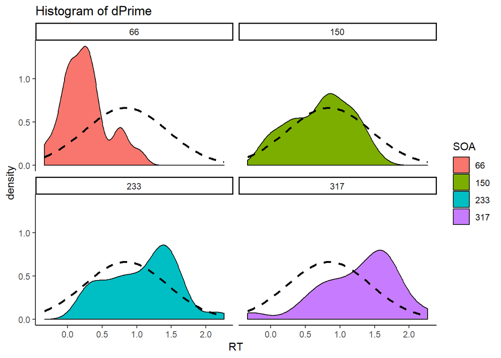

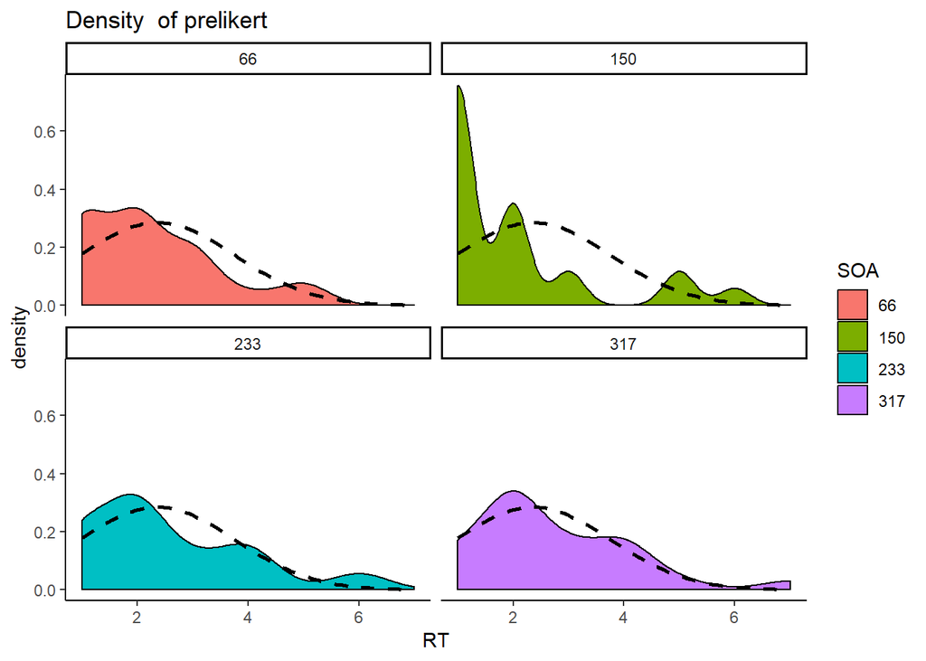

```r
histogramRT<-ggplot(data = df_summarized, aes(x=dprime, fill=SOA))+
  labs(x="RT")+
  ggtitle("Histogram of dPrime")+
  geom_density(color= 'black') +
  stat_function(fun = dnorm, colour = "Black",linetype = 2,size = 1 ,args = list(mean=mean(df_summarized$dprime), sd=sd(df_summarized$dprime))) + facet_wrap(~SOA)  + theme_classic()
histogramRT

histogramRT<-ggplot(data = df_summarized, aes(x=prelikert, fill = SOA))+
  labs(x="RT")+
  ggtitle("Density  of prelikert")+
  geom_density(color= 'black') +
  stat_function(fun = dnorm, colour = "Black",linetype = 2,size = 1, args = list(mean=mean(df_summarized$prelikert), sd=sd(df_summarized$prelikert))) + facet_wrap(~SOA)  + theme_classic()
histogramRT
```

Given this information we could affirm that there is statistical evidence to affirm that the different SOA interval has a differential effect over the conscious processing of the prime stimuli during the objective visibility test. If we take in count the evidence of the subjective report, there is no evidence to claim that the suggested processed deferentially the prime stimulus during the experimental task (priming task). Given that the attention has a crucial role on conscious processing, it could be that the short period of time (even the bigger SOA interval) combined with the focus on the processing of the target stimuli is interfering on the processing of the prime stimuli. This is coherent with Jaśkowski & Verleger (2007). They claim that for efficient masking of the prime, the prime-target interval had to be quite short (about 50 ms).

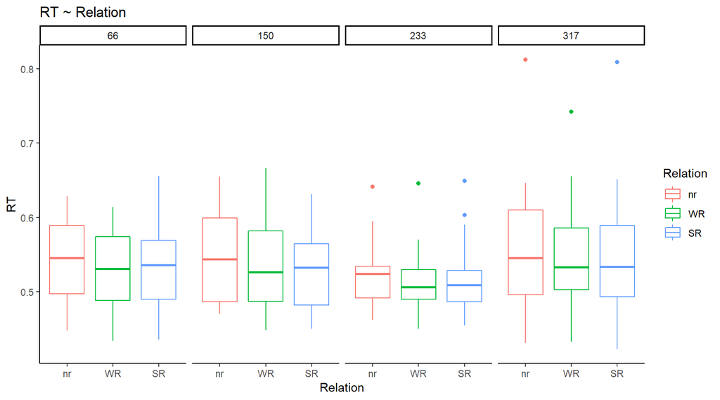

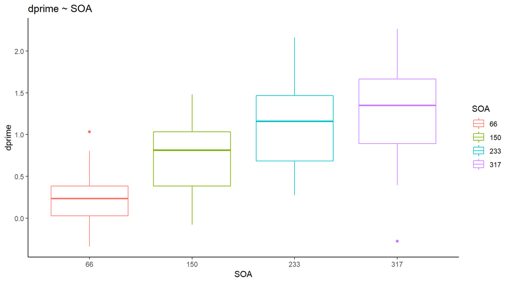

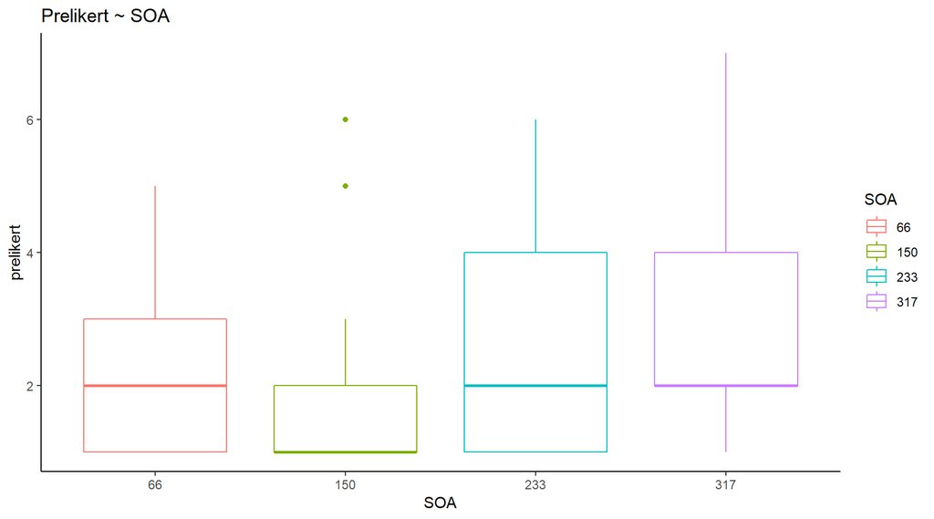

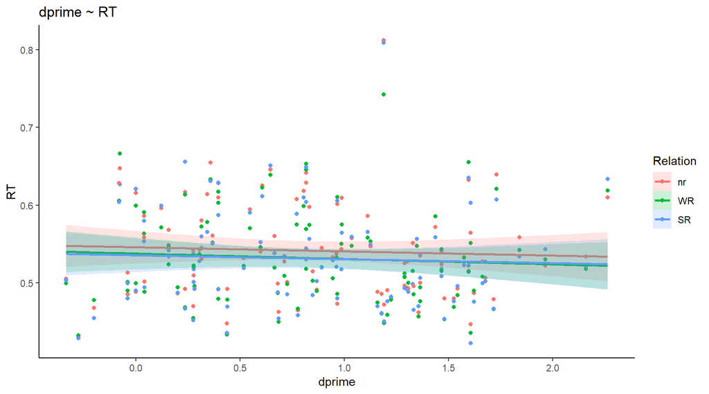

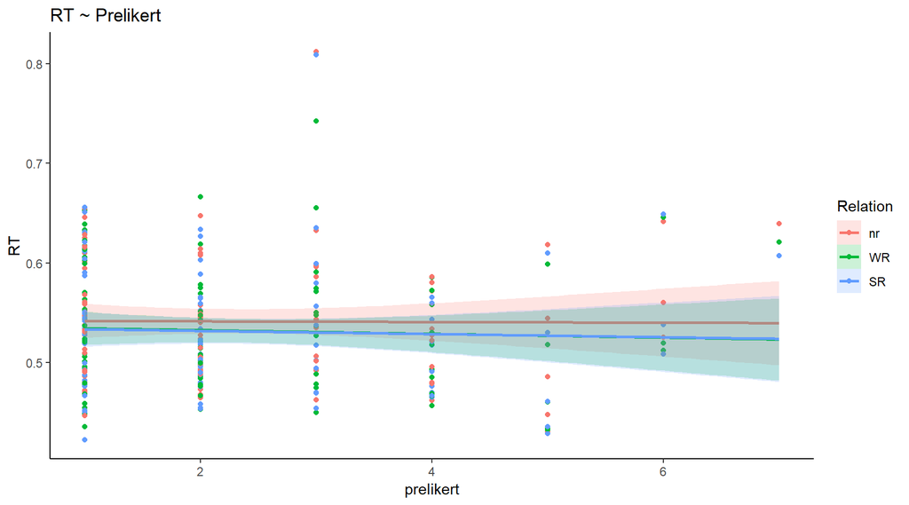

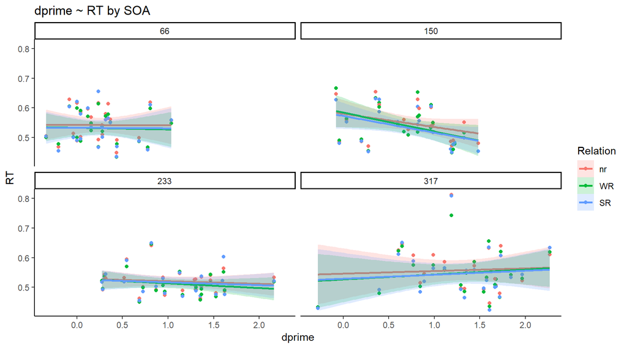

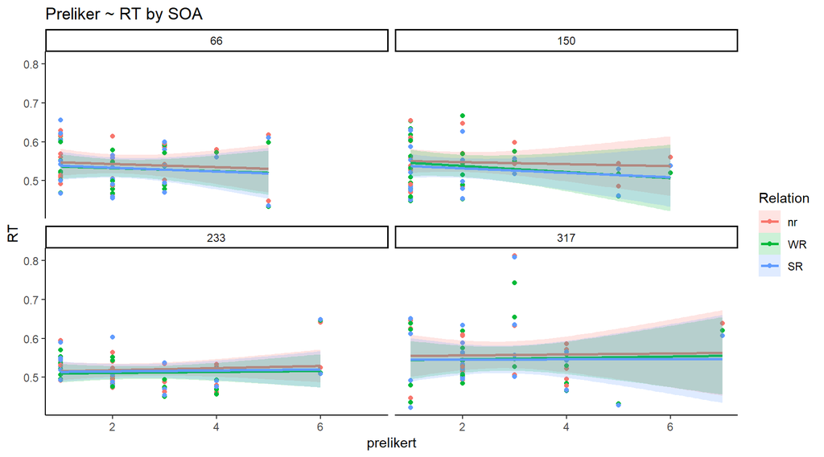

```r
#Exploratory data  graphics -----------
ggplot(data = df_summarized) + geom_boxplot(aes(x=Relation, y=RT, color = Relation)) + facet_wrap(~SOA, ncol = 4)+  theme_classic() + labs(title='RT ~ Relation')

ggplot(data = df_summarized) + geom_boxplot(aes(x=SOA, y=dprime, color = SOA)) +  theme_classic() +labs(title='dprime ~ SOA')

ggplot(data = df_summarized) + geom_boxplot(aes(x=SOA, y=prelikert, color = SOA))+  theme_classic()+ labs(title='Prelikert ~ SOA')

#General linear relation
ggplot(data = df_summarized,aes(x=dprime, y=RT, color = Relation, fill = Relation)) + geom_point()+ geom_smooth(method = lm, alpha=0.2)  +  theme_classic() + labs(title='dprime ~ RT')

ggplot(data = df_summarized,aes(x=prelikert, y=RT, color = Relation, fill = Relation)) + geom_point()+ geom_smooth(method = lm, alpha=0.2)  +  theme_classic() + labs(title='RT ~ Prelikert')

# Linear relations by group
ggplot(data = df_summarized,aes(x=dprime, y=RT, color = Relation, fill = Relation)) + geom_point()+ geom_smooth(method = lm, alpha=0.2) + facet_wrap(~SOA) +  theme_classic() + labs(title='dprime ~ RT by SOA')

ggplot(data = df_summarized,aes(x=prelikert, y=RT, color = Relation, fill = Relation)) + geom_point()+ geom_smooth(method = lm, alpha=0.2) + facet_wrap(~SOA) +  theme_classic() + labs(title='Preliker ~ RT by SOA')
```

Checking distribution of RT

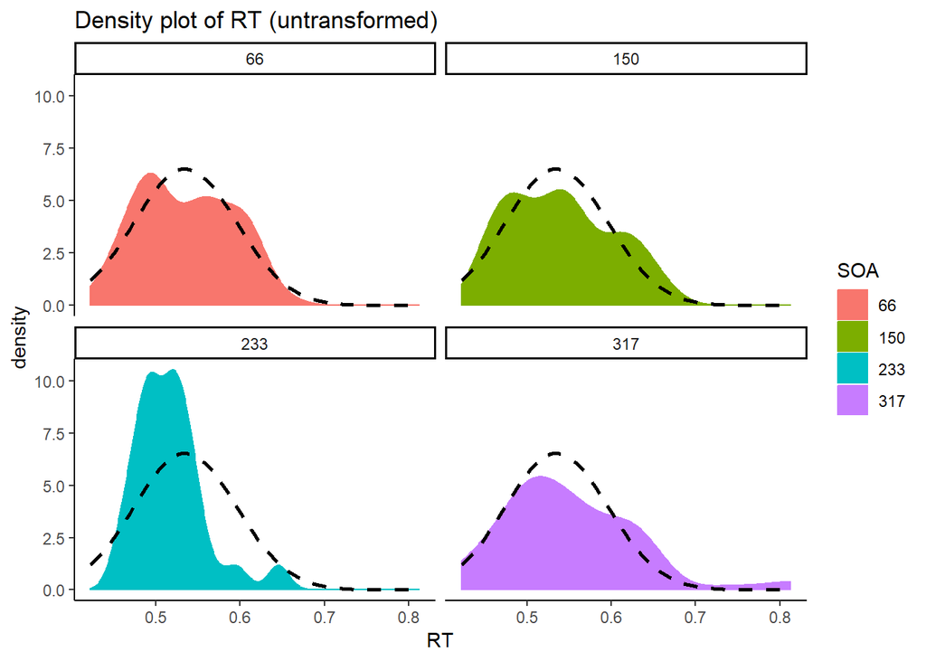

```r
#RESPONSE TIME AND SOA GROUPS ------
histogramRT<-ggplot(df_summarized, aes(x=RT, color = SOA , fill = SOA))+
  labs(x="RT")+
  ggtitle("Density plot of RT (untransformed)") +
  geom_density( )+
  stat_function(fun = dnorm, colour = "Black" , linetype = 2,size = 1, args = list(mean=mean(df_summarized$RT), sd=sd(df_summarized$RT))) + facet_wrap(~SOA)  + theme_classic()
histogramRT
```

```r
#Checking assumptions
car::leveneTest(df_summarized$RT, df_summarized$SOA, center = median) #Not homogeneous
```

```
## Levene's Test for Homogeneity of Variance (center = median)
##        Df F value    Pr(>F)
## group   3  8.9569 1.069e-05 ***
##       296
## ---
## Signif. codes:  0 '***' 0.001 '**' 0.01 '*' 0.05 '.' 0.1 ' ' 1
```

```r
tapply(df_summarized$RT, df_summarized$SOA, shapiro.test) #Not normality
```

```
## $`66`
##
##  Shapiro-Wilk normality test
##
## data:  X[[i]]
## W = 0.9634, p-value = 0.03448
##
##
## $`150`
##
##  Shapiro-Wilk normality test
##
## data:  X[[i]]
## W = 0.94997, p-value = 0.006214
##
##
## $`233`
##
##  Shapiro-Wilk normality test
##
## data:  X[[i]]
## W = 0.91152, p-value = 3.479e-05
##
##
## $`317`
##
##  Shapiro-Wilk normality test
##
## data:  X[[i]]
## W = 0.93164, p-value = 0.0005575
```

When we checked the normality on the RT variable for the treatment groups we observed that the groups are not homogeneous (Levene test F(3,296)= 8.956, p < .001) and also don’t follow a normal distribution (Shapiro Walk test, ps < .05 for all groups)

Applyng transformations to the RT data.

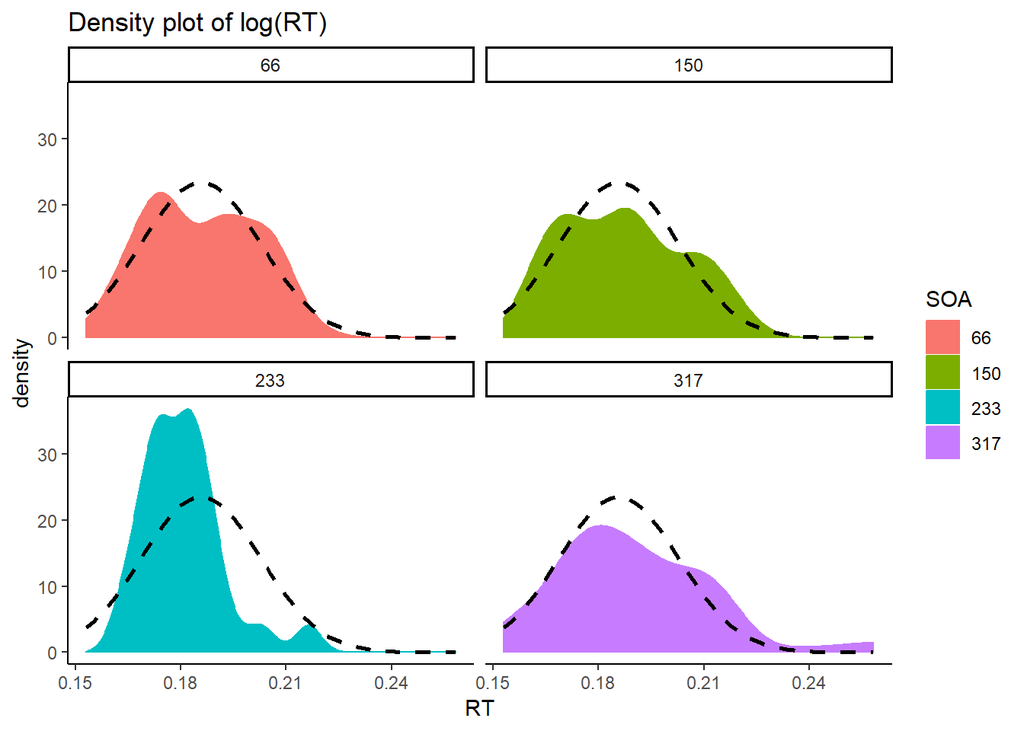

```r
# Using logaritmic transformation
df_transf = df_summarized
df_transf$RT = log10(df_transf$RT+1)
#Checking distribution Response time
histogramRT<-ggplot(df_transf, aes(x=RT, color = SOA , fill = SOA))+
  labs(x="RT")+
  ggtitle("Density plot of log(RT)")+
  geom_density()+
  stat_function(fun = dnorm, colour = "Black", linetype = 2,size = 1, args = list(mean=mean(df_transf$RT), sd=sd(df_transf$RT))) + facet_wrap(~SOA)  + theme_classic()
histogramRT #Not changes
```

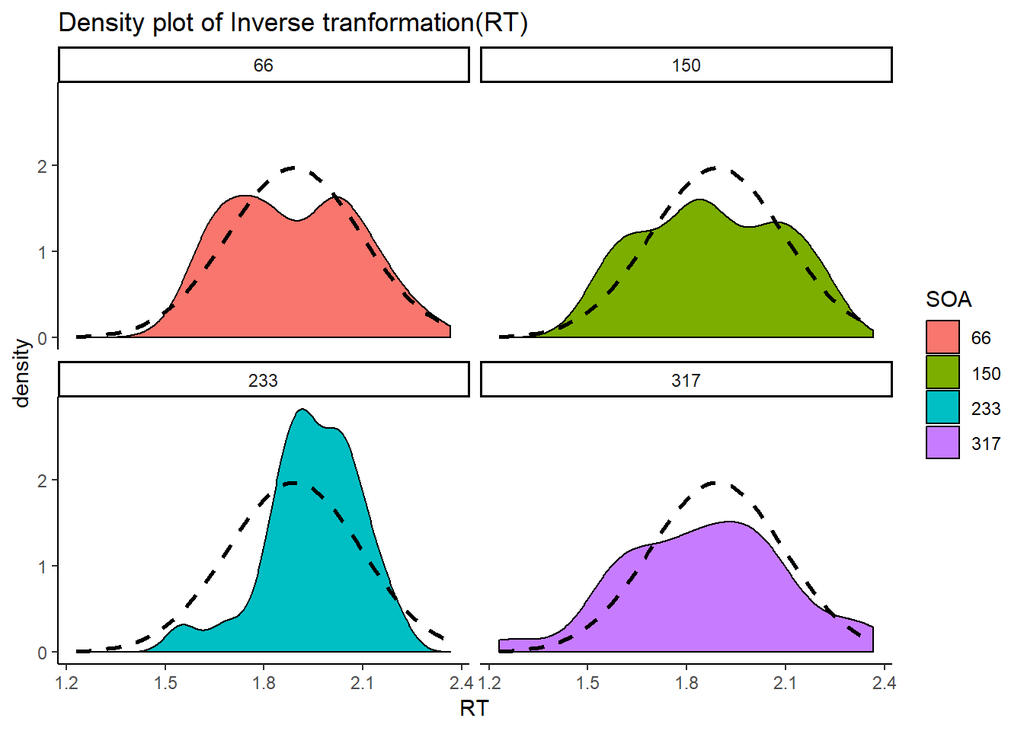

```r
#Inverse transformation ----
df_inv = df_summarized
df_inv$RT = 1/df_inv$RT
histogramRT<-ggplot(df_inv, aes(x=RT, fill = SOA))+
  labs(x="RT")+
  ggtitle("Density plot of Inverse tranformation(RT) ")+
  geom_density(color = 'black')+
  stat_function(fun = dnorm, colour = "Black", size = 1, linetype= 2, args = list(mean=mean(df_inv$RT), sd=sd(df_inv$RT))) + facet_wrap(~SOA)  + theme_classic()
histogramRT
```

```r
#Check assumptions
car::leveneTest(df_inv$RT, df_inv$SOA, center = median) #Las variables  NO son homogeneas!!
```

```
## Levene's Test for Homogeneity of Variance (center = median)
##        Df F value    Pr(>F)
## group   3  8.0344 3.649e-05 ***
##       296
## ---
## Signif. codes:  0 '***' 0.001 '**' 0.01 '*' 0.05 '.' 0.1 ' ' 1
```

```r
tapply(df_inv$RT, df_inv$SOA, shapiro.test) #NO da normal!!!!
```

```
## $`66`
##
##  Shapiro-Wilk normality test
##
## data:  X[[i]]
## W = 0.96364, p-value = 0.03559
##
##
## $`150`
##
##  Shapiro-Wilk normality test
##
## data:  X[[i]]
## W = 0.956, p-value = 0.01321
##
##
## $`233`
##
##  Shapiro-Wilk normality test
##
## data:  X[[i]]
## W = 0.96145, p-value = 0.01554
##
##
## $`317`
##
##  Shapiro-Wilk normality test
##
## data:  X[[i]]
## W = 0.98278, p-value = 0.4016
```

I tried to apply logarithmic and inverse transformation to the data in order to homogenize the data. Despite that the variance among groups remained different. The original intention was to realize a Mixed design ANOVA 4x3 where:

[output not shown]

Lastly, we would perform some non parametric test with every group individually. In order to do that, we are going to use the Friedman Test (in the markdown an alternative approach is mentioned).

```r
# Friedman Test ----
friedman.test(RT ~ Relation|ID, data = df_summarized[df_summarized$SOA == '66',])
##
##  Friedman rank sum test
##
## data:  RT and Relation and ID
## Friedman chi-squared = 12.333, df = 2, p-value = 0.002098
friedman.test(RT ~ Relation|ID, data = df_summarized[df_summarized$SOA == '150',])
##
##  Friedman rank sum test
##
## data:  RT and Relation and ID
## Friedman chi-squared = 7, df = 2, p-value = 0.0302
friedman.test(RT ~ Relation|ID, data = df_summarized[df_summarized$SOA == '233',])
##
##  Friedman rank sum test
##
## data:  RT and Relation and ID
## Friedman chi-squared = 2.7407, df = 2, p-value = 0.254
friedman.test(RT ~ Relation|ID, data = df_summarized[df_summarized$SOA == '317',])
##
##  Friedman rank sum test
##
## data:  RT and Relation and ID
## Friedman chi-squared = 6.72, df = 2, p-value = 0.03474
#dffinal %>% group_by(SOA, Relation) %>% summarise(meanRT = mean((RT)), sd = sd((RT)))
```

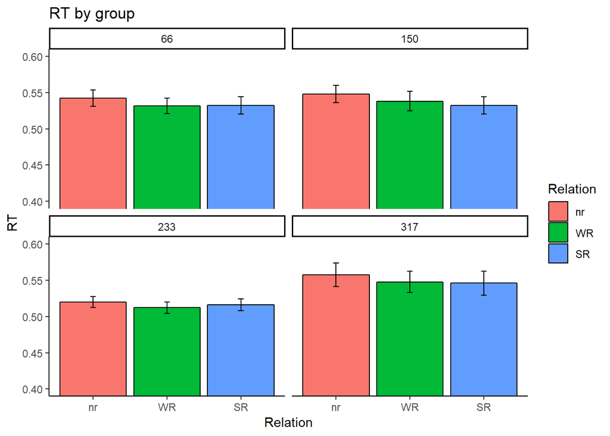

```r
 ggplot(data= datos, aes(x=Relation, y=mean, fill = Relation)) + geom_bar(position = 'dodge', stat = 'identity' ,color= 'black') + facet_wrap(~SOA) + theme_classic() + coord_cartesian(ylim = c(0.4, 0.6)) + geom_errorbar(aes(ymin=mean-se, ymax=mean+se), width = .075, colour ="black") + ylab('RT') + labs(title = 'RT by group')
```